# Practical edgeR

2016-11-30

## Teachers and slides

- **Malte Thodberg**
- PhD Student ~ 1 year
- Focus: Clinical Bioinformatics
- Mail: `malte.thodberg@bio.ku.dk`
- Background: BSc Molecular Biomedicine & MSc Bioinformatics

## Practical Outline

The plan:

- Introduction to `model.matrix` for building model matrices
- Example analysis on a single dataset
- Play around with the remaining datasets.

## Datasets

Example datasets:

- `iris` dataset from `datasets` (default R-package).
- `oliveoil` dataset from the `pdfCluster` package.

Real datasets:

- `zebrafish` dataset
- `fission` dataset
- `pasilla` dataset

Advanced dataset for playing around:

- `tissues` dataset

## Design and model matrices

## R is a statistical programming language

R has a powerful built-in language for linear models, making it simple to form a model matrix (0-1) representation of a design matrix.

This is done by using the `model.matrix` function with the build in formula language (preceded by `~`).

Let's make a simple dummy design we can explore

```r
dummy <- data.frame(factor1=c("A", "A", "B", "B", "A", "A", "B", "B"),
                                         factor2=c("C", "C", "C", "C", "D", "D", "D", "D"))

dummy
```

```
##   factor1 factor2
## 1       A       C
## 2       A       C
## 3       B       C
## 4       B       C
## 5       A       D
## 6       A       D
## 7       B       D
## 8       B       D
```

## Basic model

Simple 2-factor design build using `~`:

```r
model.matrix(~factor1, data=dummy)
```

```
##   (Intercept) factor1B
## 1           1        0
## 2           1        0
## 3           1        1
## 4           1        1
## 5           1        0
## 6           1        0
## 7           1        1
## 8           1        1
## attr(,"assign")
## [1] 0 1
## attr(,"contrasts")
## attr(,"contrasts")$factor1
## [1] "contr.treatment"
```

## Adding more groups

3-factor design using `+`:

```r
model.matrix(~factor1+factor2, data=dummy)
```

```
##   (Intercept) factor1B factor2D
## 1           1        0        0
## 2           1        0        0
## 3           1        1        0
## 4           1        1        0
## 5           1        0        1
## 6           1        0        1
## 7           1        1        1
## 8           1        1        1
## attr(,"assign")
## [1] 0 1 2
## attr(,"contrasts")
## attr(,"contrasts")$factor1
## [1] "contr.treatment"
##
## attr(,"contrasts")$factor2
## [1] "contr.treatment"
```

## Interaction terms

An an interaction term using `:`:

```r
model.matrix(~factor1+factor2+factor1:factor2, data=dummy)
```

```
##   (Intercept) factor1B factor2D factor1B:factor2D
## 1           1        0        0                 0
## 2           1        0        0                 0
## 3           1        1        0                 0
## 4           1        1        0                 0
## 5           1        0        1                 0
## 6           1        0        1                 0
## 7           1        1        1                 1
## 8           1        1        1                 1
## attr(,"assign")
## [1] 0 1 2 3
## attr(,"contrasts")
## attr(,"contrasts")$factor1
## [1] "contr.treatment"
##
## attr(,"contrasts")$factor2
## [1] "contr.treatment"
```

## Interaction terms

`*` is shorthand for both base levels and interactions:

```r
model.matrix(~factor1*factor2, data=dummy)
```

```
##   (Intercept) factor1B factor2D factor1B:factor2D
## 1           1        0        0                 0
## 2           1        0        0                 0
## 3           1        1        0                 0
## 4           1        1        0                 0
## 5           1        0        1                 0
## 6           1        0        1                 0
## 7           1        1        1                 1
## 8           1        1        1                 1
## attr(,"assign")
## [1] 0 1 2 3
## attr(,"contrasts")
## attr(,"contrasts")$factor1
## [1] "contr.treatment"
##
## attr(,"contrasts")$factor2
## [1] "contr.treatment"
```

## Formula cheat sheet.

The R formula interface is almost a programming language in itself!

Due to it's expressiveness, it's used by huge number of packages, making it well worth the effort to learn.

See this cheatsheet for an overview:

https://ww2.coastal.edu/kingw/statistics/R-tutorials/formulae.html

## First steps with edgeR

## Trimming and normalizing the data.

Just as before, we started by loading, trimming and normalizing the data:

```r
# Load the data
library(Shenzen2016)
library(ggplot2)
library(edgeR)
data("zebrafish")

# Trim
EM_zebra <- subset(zebrafish$Expression, rowSums(zebrafish$Expression >= 5) >= 3)

# Calculate normalization factors
dge_zebra <- DGEList(EM_zebra)
dge_zebra <- calcNormFactors(dge_zebra, method="TMM")
```

## Building the model matrix

Before we can estimate dispersions, we must decide on our model matrix. Recall the simpel design of the `zebrafish` dataset:

```r
zebrafish$Design
```

```
##       gallein
## Ctl1  control
## Ctl3  control
## Ctl5  control
## Trt9  treated
## Trt11 treated
## Trt13 treated
```

We use `model.matrix` to make a simple model matrix:

```r
mod <- model.matrix(~gallein, data=zebrafish$Design)
```

## Estimating the dispersion

Now we move on to estimating dispersion or BCV:

```r
disp_zebra <- estimateDisp(dge_zebra, design=mod, robust=TRUE)
```

The 3-step estimation is all done by a single function in the newest version of edgeR: `estimateDisp`, which replaces the three previous functions of

- `estimateCommonDisp`
- `estimateTrendedDisp`
- `estimateTagwiseDisp`

## Plotting the dispersion

We can then plot the estimates:

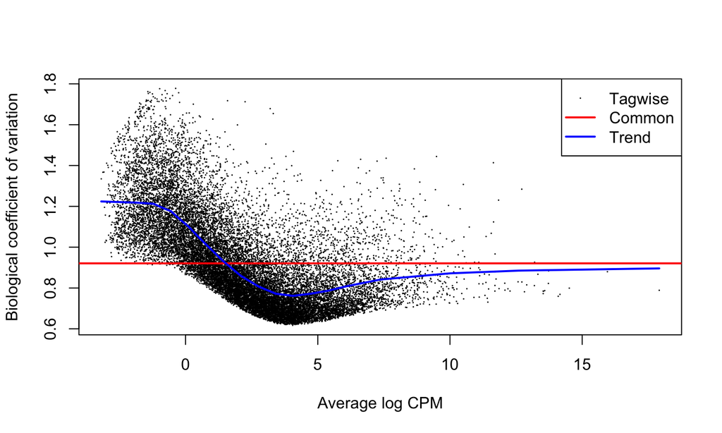

```r
plotBCV(y=disp_zebra)
```

## Fiting gene-wise GLMs and testing a coefficient.

Now we can fit gene-wise GLMs:

```r
fit_zebra <- glmFit(disp_zebra, design=mod)
```

Finally, we can test a coefficient in the model for DE:

```r
# Using the name of the coefficient
gallein <- glmLRT(fit_zebra, coef="galleintreated")

# Using the index of the coefficient
gallein <- glmLRT(fit_zebra, coef=2)
```

## Inspecting the results

edgeR has several useful functions for inspecting and plotting the results:

Inspecting the top hits with `topTags`:

```r
topTags(gallein)
```

```
## Coefficient:  galleintreated
##                        logFC      logCPM       LR       PValue        FDR
## ENSDARG00000075505 -7.050262  0.91117648 23.80734 1.064758e-06 0.02100555
## ENSDARG00000002508 -6.899410  1.98202488 22.20446 2.451042e-06 0.02295301
## ENSDARG00000091349 -8.890035  2.67150109 20.55462 5.795375e-06 0.02295301
## ENSDARG00000069441 -9.167127 -0.06217613 20.49840 5.968101e-06 0.02295301
## ENSDARG00000071565  7.114208  0.34425608 20.11430 7.294911e-06 0.02295301
## ENSDARG00000087178 -9.267206  0.03576790 19.88493 8.224602e-06 0.02295301
## ENSDARG00000040128  7.387525  6.64510937 19.77345 8.718553e-06 0.02295301
## ENSDARG00000090689  5.949190  4.67990013 19.49344 1.009458e-05 0.02295301
## ENSDARG00000000906 -8.272187  1.30746230 19.42346 1.047126e-05 0.02295301
## ENSDARG00000076643 -7.572012  0.42975453 18.64501 1.574592e-05 0.02740671
```

## Inspecting the results

Summarize the number of up- and down-regulated genes with `decideTestsDGE`:

```r
is_de <- decideTestsDGE(gallein, p.value=0.1)
head(is_de)
```

```
##      [,1]
## [1,]    0
## [2,]    0
## [3,]    0
## [4,]    0
## [5,]    0
## [6,]    0
```

```r
summary(is_de)
```

```
##    [,1]
## -1    68
## 0  19581
## 1     79
```

## Inspecting the results

MA-plot, showing relation between mean expression and logFC, :

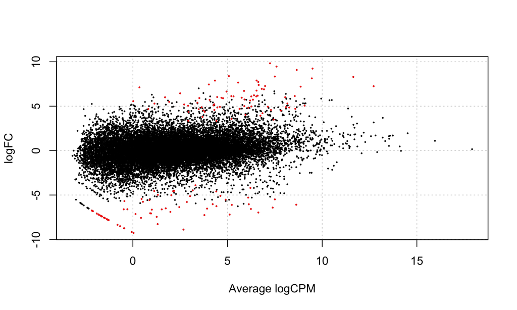

```r
plotSmear(gallein, de.tags=rownames(gallein)[is_de != 0])
```

## Inspecting the results

There is no built-in function for making a volcano plot, but it's easy to do yourself:

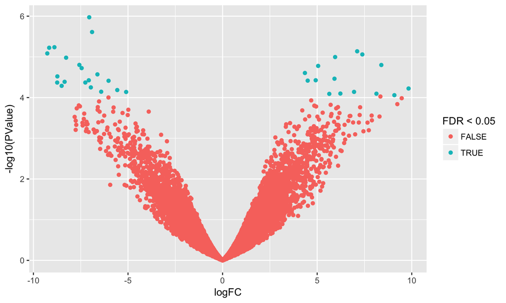

```r
res <- as.data.frame(topTags(gallein, n=Inf, sort.by="none"))
ggplot(res, aes(x=logFC, y=-log10(PValue), color=FDR < 0.05)) + geom_point()
```

## Quasi-likelihood: Fitting models

```r
fitQL <- glmQLFit(y=disp_zebra, design=mod, robust=TRUE)
galleinQL <- glmQLFTest(fitQL, coef="galleintreated")
summary(decideTestsDGE(galleinQL, p.value=0.1))
```

```
##    [,1]
## -1     0
## 0  19728
## 1      0
```

## Quasi-likehood: Plotting dispersions

The QL-pipeline estimates slightly different dispersions:

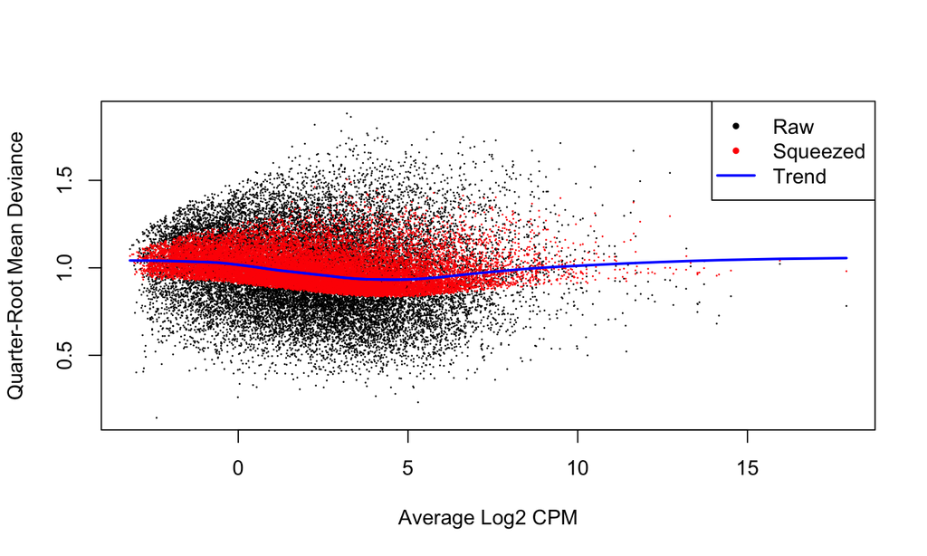

```r
plotQLDisp(fitQL)
```

## Final exercises:

Use the above code as a template for conducting your own analysis. For the `yeast` and `pasilla` datasets:

- Load, trim and normalize the data
- Inspect the study design, and decide on a model matrix to use with edgeR
- Use edgeR to estimate dispersions and fit gene-wise GLMs
- Report the number of up- and down-regulated genes for the tests of interests
- Generate smear and volcano plots summarizing the analysis.

If you have time:

- Investigate the effect of different normalization methods.
- Try out the QL-pipeline by replacing `glmFit` with `glmQLFit` and `glmLRT` with `glmQLFTest`
- Refering the slides, see if you can also test a contrast by using a contrast-vector of the form: `c(0,0,-1,1)`

Once again - the next couple of slides contain cheat sheets.

## Cheatsheet: Experimenting with model matrices

```r
# Load the data
data("yeast")
data("pasilla")

# Set a datasets
dataset <- pasilla

# Experiment with model matrices
mod <- model.matrix(~condition, data=dataset$Design)

# Look how the experiment is designed
dataset$Design
```

```
##              condition        type
## treated1fb     treated single-read
## treated2fb     treated  paired-end
## treated3fb     treated  paired-end
## untreated1fb untreated single-read
## untreated2fb untreated single-read
## untreated3fb untreated  paired-end
## untreated4fb untreated  paired-end
```

## Cheatsheet: Fitting the models

```r
# Trim
EM <- subset(dataset$Expression, rowSums(dataset$Expression >= 5) >= 3)

# Calculate normalization factors
dge <- calcNormFactors(DGEList(EM), method="TMM")

# Calculate dispersion
disp <- estimateDisp(dge, design=mod, robust=TRUE)

# Fit models
fit <- glmFit(disp, design=mod)

# Perform the test of the given coefficient
res <- glmLRT(fit, coef="conditionuntreated")
```

## Cheatsheet: Inspecting the results

```r
# Dispersion
plotBCV(disp)

# topTages
topTags(res)

# Up and down regulated genes
summary(decideTestsDGE(res))

# Smear plot
plotSmear(res, de.tags=rownames(res)[decideTestsDGE(res) != 0])

# Volcano
all_genes <- as.data.frame(topTags(res, n=Inf, sort.by="none"))
ggplot(all_genes, aes(x=logFC, y=-log10(PValue), color=FDR < 0.05)) + geom_point()
```